# Analysis Immigrant Experiment Data with OLS, Logistic Model and Conditional Logistic Model, Plus Clustering

Wei-Lun, Lin

2026-03-04

- 背景: 以 OLS, logistic regression, conditional logistic regression 分析 Hainmueller et al. (2014) 的 immigrant experiment 資料，並於此文件進一步比較 1. 有無加入交互作用、2. 有無對受試者層次做 cluster-robust standand error 對於估計上的差異。

## Immigrant Experiment

```r
immigrant <- read_rds("../1-data/2-processed/immigrant_data.rds")
immigrant <- immigrant %>%
  mutate(
    id = row_number(),
    alt_id = id + 3 - 2 * profile
  )

immigrant %>%
  head() %>%
  kable("html", caption="First 6 Rows of immigrant Data") %>%
  kable_styling(bootstrap_options = c("striped", "hover", "condensed"), full_width = F) %>%
  scroll_box(width = "100%")
```

First 6 Rows of immigrant Data

| subject | trial_id | profile_id | select | subject_trial_id | Education. | Gender. | Origin. | ApplicationReason. | Profession. | JobExperience. | JobPlans. | PriorTripstoUS. | Language. | ethnocentrism | profile | LangPos | PriorPos | id | alt_id |
| --- | --- | --- | --- | --- | --- | --- | --- | --- | --- | --- | --- | --- | --- | --- | --- | --- | --- | --- | --- |
| 4 | 1 | 830617 | 1 | 1 | Equivalent to completing high school in the US | male | Iraq | Seek better job in U.S. | Nurse | More than five years of job training and experience | Has a contract with a U.S. employer | Entered U.S. once before on a tourist visa | During admission interview, this applicant tried to speak English but was unable | 50 | 1 | 5 | 4 | 1 | 2 |
| 4 | 1 | 1433195 | 0 | 1 | No formal education | female | France | Seek better job in U.S. | Child care provider | Three to five years of job training and experience | Does not have a contract with a U.S. employer but has done job interviews | Entered the U.S. once before without legal authorization | During admission interview, this applicant spoke [language] and used an interpreter | 50 | 2 | 5 | 4 | 2 | 1 |
| 4 | 2 | 84805 | 0 | 2 | Equivalent to completing a graduate degree in the US | female | Sudan | Escape political/religious persecution | Gardener | Three to five years of job training and experience | Has a contract with a U.S. employer | Entered U.S. once before on a tourist visa | During the admission interview, this applicant spoke fluent English | 50 | 1 | 5 | 4 | 3 | 4 |
| 4 | 2 | 34442 | 1 | 2 | Equivalent to completing fourth grade in the US | female | Germany | Reunite with family members already in the U.S. | Construction worker | More than five years of job training and experience | Does not have a contract with a U.S. employer but has done job interviews | Never been to the U.S. | During the admission interview, this applicant spoke fluent English | 50 | 2 | 5 | 4 | 4 | 3 |
| 4 | 3 | 701166 | 1 | 3 | Equivalent to completing high school in the US | female | Philippines | Seek better job in U.S. | Nurse | More than five years of job training and experience | Does not have a contract with a U.S. employer but has done job interviews | Entered the U.S. once before without legal authorization | During admission interview, this applicant spoke broken English | 50 | 1 | 5 | 4 | 5 | 6 |
| 4 | 3 | 1091 | 0 | 3 | Equivalent to completing a college degree in the US | male | Sudan | Seek better job in U.S. | Child care provider | No job training or prior experience | Has a contract with a U.S. employer | Never been to the U.S. | During the admission interview, this applicant spoke fluent English | 50 | 2 | 5 | 4 | 6 | 5 |

在 immigrant experiment 中，immigrant 有9個 attributes:

| Attribute | Level 1 | Level 2 | Level 3 | Level 4 | Level 5 | Level 6 | Level 7 | Level 8 | Level 9 | Level 10 | Level 11 |
| --- | --- | --- | --- | --- | --- | --- | --- | --- | --- | --- | --- |
| Education (7) | No formal education | Equivalent to completing fourth grade in the US | Equivalent to completing eighth grade in the US | Equivalent to completing high school in the US | Equivalent to completing two years of college in the US | Equivalent to completing a college degree in the US | Equivalent to completing a graduate degree in the US | - | - | - | - |
| Gender (2) | female | male | - | - | - | - | - | - | - | - | - |
| Origin (10) | Germany | France | Mexico | Philippines | Poland | India | China | Sudan | Somalia | Iraq | - |
| Application Reason (3) | Reunite with family members already in the U.S. | Seek better job in U.S. | Escape political/religious persecution | - | - | - | - | - | - | - | - |
| Profession (11) | Janitor | Waiter | Child care provider | Gardener | Financial analyst | Construction worker | Teacher | Computer programmer | Nurse | Research scientist | Doctor |
| Job experience (4) | No job training or prior experience | One or two years of job training and experience | Three to five years of job training and experience | More than five years of job training and experience | - | - | - | - | - | - | - |
| Job plans (4) | Has a contract with a U.S. employer | Does not have a contract with a U.S. employer but has done job interviews | Will look for work after arriving in the U.S. | Has no plans to look for work at this time | - | - | - | - | - | - | - |
| Prior trips to US (5) | Never been to the U.S. | Entered U.S. once before on a tourist visa | Has visited the U.S. many times before on tourist visas | Spent six months with family members in the U.S | Entered the U.S. once before without legal authorization | - | - | - | - | - | - |
| Language (4) | During the admission interview, this applicant spoke fluent English | During admission interview, this applicant spoke broken English | During admission interview, this applicant tried to speak English but was unable | During admission interview, this applicant spoke [language] and used an interpreter | - | - | - | - | - | - | - |

排除不合理的 profiles 後，共有 $936960$ 種 potential profiles。

此外，為了方便後續圖表呈現，先對某些 attributes 的 levels 重新命名。

```r
immigrant <- immigrant %>%
  mutate(
    Education. = as.factor(paste0("Education.", as.integer(Education.))),
    ApplicationReason. = as.factor(paste0("ApplicationReason.", as.integer(ApplicationReason.))),
    JobExperience. = as.factor(paste0("JobExperience.", as.integer(JobExperience.))),
    JobPlans. = as.factor(paste0("JobPlans.", as.integer(JobPlans.))),
    PriorTripstoUS. = as.factor(paste0("PriorTripstoUS.", as.integer(PriorTripstoUS.))),
    Language. = as.factor(paste0("Language.", as.integer(Language.)))
  )
```

## Model Fitting

因為在此實驗設計中，attributes 之間並不完全獨立（completely independent randomization）， 而是會因為現實限制而導致某些 profiles 不應該出現，例如：

- 一部份的工作 （`profession`）會和教育（`education`）有關
- 一部分移民的理由（`application reason`）會和原國家（`origin`）有關

在此種情形下，attributes 之間不再是完全獨立，而是 conditionally independent randomization。 即儘管某個 attribute A 和另一 attribute B 相關，但在給定該 attribute B 的情況下， attribute A 的分配會獨立於其他所有 attributes。 因此不能直接用只有主要效果的 models，而是要在模型中加入交互作用。

```r
est.all.immigrant <- data.frame()
```

```r
immigrant.design <- makeDesign(
  type="constraints",
  attribute.levels = list(
    "Education." = sort(unique(immigrant$Education.)),
    "Gender." = sort(unique(immigrant$Gender.)),
    "Origin." = sort(unique(immigrant$Origin.)),
    "ApplicationReason." = sort(unique(immigrant$ApplicationReason.)),
    "Profession." = sort(unique(immigrant$Profession.)),
    "JobExperience." = sort(unique(immigrant$JobExperience.)),
    "JobPlans." = sort(unique(immigrant$JobPlans.)),
    "PriorTripstoUS." = sort(unique(immigrant$PriorTripstoUS.)),
    "Language." = sort(unique(immigrant$Language.))
  ),
  constraints = list(
    list(
      "Education." = c("Education.1", "Education.2", "Education.3", "Education.4"),
      "Profession." = c("Financial analyst", "Computer programmer", "Doctor", "Research scientist")
    ),
    list(
      "ApplicationReason." = c("ApplicationReason.3"),
      "Origin." = c("Germany", "France", "Mexico", "Philippines", "Poland", "India")
    )
  )
)

form.immigrant <- select ~ Education. + Gender. + Origin. + ApplicationReason. + Profession. + JobExperience. + JobPlans. + PriorTripstoUS. + Language.
form_int.immigrant <- select ~ Gender. + JobExperience. + JobPlans. + PriorTripstoUS. + Language. + Education. * Profession. + Origin. * ApplicationReason.
```

### immigrant: Linear Regression

根據 Hainmueller et al. (2014)， 可以用 ordinary least squares (OLS) regression 來估計 attributes 各個 levels 的 average marginal component effects (AMCE)， 即平均掉其他 attributes 的影響後，該 level 的邊際效果。 在 immigrant experiment 這樣的 2AFC 的 task 中，估計出來的數值為「該 term 出現時，選項被選擇機率的增減」。

```r
# OLS without interaction
ols.immigrant <- fit_model(form.immigrant, dat = immigrant, model = "ols")
est.all.immigrant <- ols.immigrant[[2]] %>%
  select(-c(statistic, p.value)) %>%
  mutate(
    CI.lower = estimate - 1.96*std.error,
    CI.upper = estimate + 1.96*std.error
  ) %>%
  rename_with(~ paste0(.x, ".OLS"), .cols = -c(attribute, term))

# OLS with clustering and without interaction
ols_clus.immigrant <- fit_model(form.immigrant, dat = immigrant, model = "ols", cluster = "subject")
est.all.immigrant <- ols_clus.immigrant[[2]] %>%
  select(-c(statistic, p.value)) %>%
  mutate(
    CI.lower = estimate - 1.96*std.error,
    CI.upper = estimate + 1.96*std.error
  ) %>%
  rename_with(~ paste0(.x, ".OLS_clustered"), .cols = -c(attribute, term)) %>%
  left_join(est.all.immigrant, ., by = join_by(attribute, term))

# OLS with interaction
# this part is completed with the `amce` function in the `cjoint` package
ols_int.immigrant <- fit_model(form.immigrant, dat = immigrant, model = "amce", design = immigrant.design)
est.all.immigrant <- ols_int.immigrant[[2]] %>%
  select(-c(statistic, p.value)) %>%
  mutate(
    CI.lower = estimate - 1.96*std.error,
    CI.upper = estimate + 1.96*std.error
  ) %>%
  rename_with(~ paste0(.x, ".OLS_interact"), .cols = -c(attribute, term)) %>%
  left_join(est.all.immigrant, ., by = join_by(attribute, term))

# OLS with clustering and interaction
ols_int_clus.immigrant <- fit_model(form.immigrant, dat = immigrant, model = "amce", design = immigrant.design, cluster = "subject")
est.all.immigrant <- ols_int_clus.immigrant[[2]] %>%
  select(-c(statistic, p.value)) %>%
  mutate(
    CI.lower = estimate - 1.96*std.error,
    CI.upper = estimate + 1.96*std.error
  ) %>%
  rename_with(~ paste0(.x, ".OLS_interact_clustered"), .cols = -c(attribute, term)) %>%
  left_join(est.all.immigrant, ., by = join_by(attribute, term))
```

再把 OLS 計算出來的 AMCE 另外儲存。

```r
AME.immigrant <- est.all.immigrant
```

比較加入或未加入交互作用的 OLS 模型，並且同時檢驗控制或不控制 cluster-robust standard error 後的 CI：

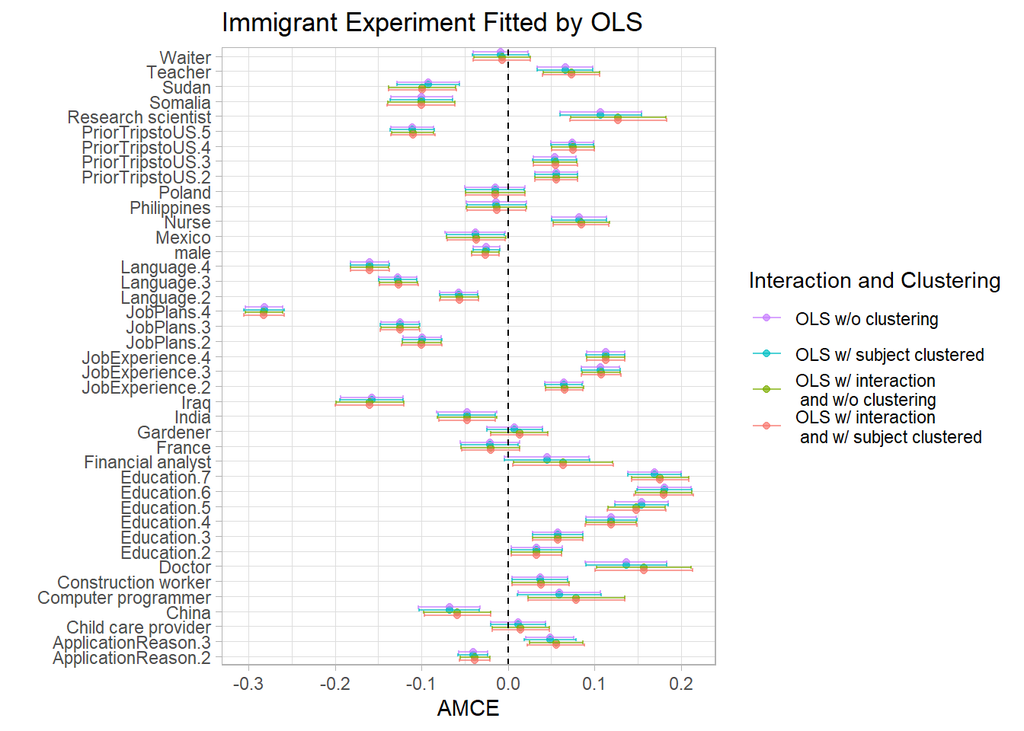

```r
ols.plot.immigrant <- est.all.immigrant %>%
  filter(!grepl(":", term)) %>%  # discard interaction terms
  select(c(attribute, term, contains("OLS"))) %>%
  select(c(attribute, term, starts_with("estimate."), starts_with("CI."))) %>%
  pivot_longer(
    cols = -c(attribute, term),
    names_to = c(".value", "model"),
    names_pattern = "(.*)\\.(OLS.*)$"
  ) %>%
  mutate(
    model = fct_recode(
      model,
      "OLS w/o clustering" = "OLS",
      "OLS w/ subject clustered" = "OLS_clustered",
      "OLS w/ interaction\n and w/o clustering" = "OLS_interact",
      "OLS w/ interaction\n and w/ subject clustered" = "OLS_interact_clustered"
    )
  ) %>%
  mutate(model = fct_rev(model)) %>%
  plot_result(., n.mod = 2) +
  labs(title = "Immigrant Experiment Fitted by OLS", x = "AMCE", color="Interaction and Clustering")

# ggsave("./1-figure/res-immigrant-OLS.png", ols.plot.immigrant)

ols.plot.immigrant
```

可以發現加入交互作用後，那些有相關的 attributes 的確會有影響。

### Logistic Regression

```r
# w/o interaction
logit.immigrant <- fit_model(form.immigrant, dat = immigrant, model = "logit")
logit_clus.immigrant <- fit_model(form.immigrant, dat = immigrant, model = "logit", cluster = "subject")

est.all.immigrant <- logit.immigrant[[2]] %>%
  select(-c(statistic, p.value)) %>%
  mutate(
    CI.lower = estimate - 1.96*std.error,
    CI.upper = estimate + 1.96*std.error
  ) %>%
  rename_with(~ paste0(.x, ".logit"), .cols = -c(attribute, term)) %>%
  left_join(est.all.immigrant, ., by = join_by(attribute, term))
est.all.immigrant <- logit_clus.immigrant[[2]] %>%
  select(-c(statistic, p.value)) %>%
  mutate(
    CI.lower = estimate - 1.96*std.error,
    CI.upper = estimate + 1.96*std.error
  ) %>%
  rename_with(~ paste0(.x, ".logit_clustered"), .cols = -c(attribute, term)) %>%
  left_join(est.all.immigrant, ., by = join_by(attribute, term))

# w/ interaction
logit_int.immigrant <- fit_model(form_int.immigrant, dat = immigrant, model = "logit")
logit_int_clus.immigrant <- fit_model(form_int.immigrant, dat = immigrant, model = "logit", cluster = "subject")

est.all.immigrant <- logit_int.immigrant[[2]] %>%
  select(-c(statistic, p.value)) %>%
  mutate(
    CI.lower = estimate - 1.96*std.error,
    CI.upper = estimate + 1.96*std.error
  ) %>%
  rename_with(~ paste0(.x, ".logit_interact"), .cols = -c(attribute, term)) %>%
  right_join(est.all.immigrant, ., by = join_by(attribute, term))
est.all.immigrant <- logit_int_clus.immigrant[[2]] %>%
  select(-c(statistic, p.value)) %>%
  mutate(
    CI.lower = estimate - 1.96*std.error,
    CI.upper = estimate + 1.96*std.error
  ) %>%
  rename_with(~ paste0(.x, ".logit_interact_clustered"), .cols = -c(attribute, term)) %>%
  left_join(est.all.immigrant, ., by = join_by(attribute, term))
```

Plot the result of logistic regression.

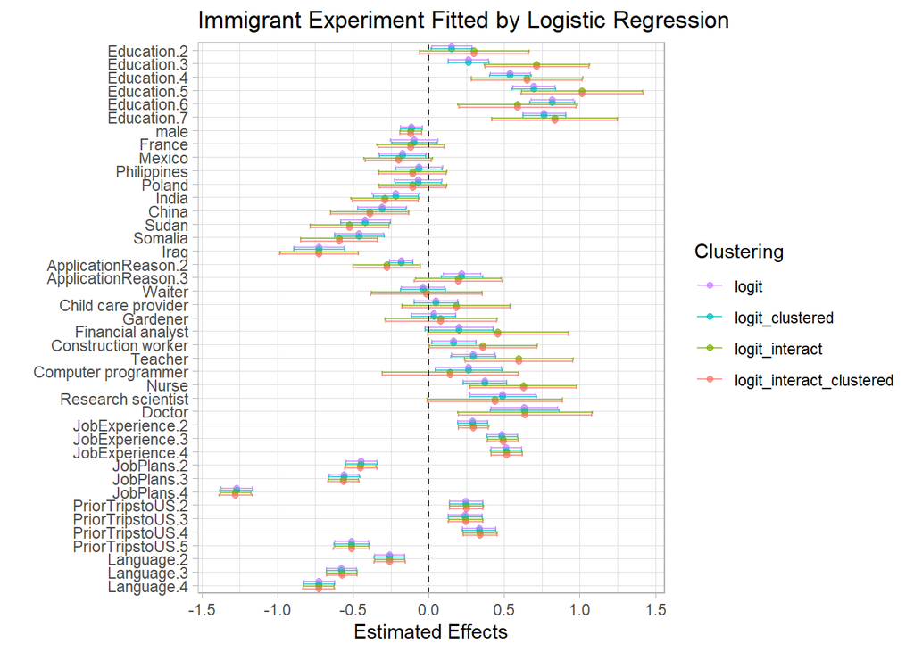

```r
logit.plot.immigrant <- est.all.immigrant %>%
  select(c(
    attribute, term, (
      contains("logit") & (starts_with("estimate.") | starts_with("CI."))
    )
  )) %>%
  filter(!grepl(":", term)) %>%
  mutate(term = factor(term, levels = rev(term))) %>%
  pivot_longer(
    cols = -c(attribute, term),
    names_to = c(".value", "model"),
    names_pattern = "(.*)\\.(logit.*)$"
  ) %>%
  mutate(model = fct_rev(model)) %>%
  # mutate(
  #   model = fct_recode(
  #     model,
  #     "Logistic regression\n without clustering" = "logit",
  #     "Logistic regression\n with subject clustered" = "logit_clustered",
  #     "Logistic regression\n without clustering" = "logit_interact",
  #     "Logistic regression\n with subject clustered" = "logit_clustered",
  #   )
  # ) %>%
  plot_result(., n.mod = 2) +
  labs(title = "Immigrant Experiment Fitted by Logistic Regression", x = "Estimated Effects", color="Clustering")

# ggsave("./1-figure/res-immigrant-logit.png", logit.plot.immigrant)
logit.plot.immigrant
```

#### AME of Logistic Regression

分別計算有無交互作用模型的 average marginal effect (AME)。

```
## Found the file of AME of Logistic without interaction and clustering!
##
##       Reading file...
```

```
## Found the file of AME of Logistic without interaction and with clustering!
##
##       Reading file...
```

AME of Logistic Regression Model for immigrant Experiment

| term | contrast | estimate | std.error | statistic | p.value | s.value | conf.low | conf.high |
| --- | --- | --- | --- | --- | --- | --- | --- | --- |
| ApplicationReason | ApplicationReason.2 - ApplicationReason.1 | -0.040 | 0.009 | -4.682 | 0.000 | 18.424 | -0.057 | -0.023 |
| ApplicationReason | ApplicationReason.3 - ApplicationReason.1 | 0.048 | 0.014 | 3.493 | 0.000 | 11.032 | 0.021 | 0.075 |
| Education | Education.2 - Education.1 | 0.033 | 0.015 | 2.256 | 0.024 | 5.377 | 0.004 | 0.063 |
| Education | Education.3 - Education.1 | 0.058 | 0.015 | 3.869 | 0.000 | 13.157 | 0.028 | 0.087 |
| Education | Education.4 - Education.1 | 0.120 | 0.015 | 8.032 | 0.000 | 49.885 | 0.091 | 0.149 |
| Education | Education.5 - Education.1 | 0.154 | 0.016 | 9.911 | 0.000 | 74.499 | 0.124 | 0.185 |
| Education | Education.6 - Education.1 | 0.181 | 0.016 | 11.627 | 0.000 | 101.396 | 0.151 | 0.212 |
| Education | Education.7 - Education.1 | 0.170 | 0.016 | 10.893 | 0.000 | 89.383 | 0.139 | 0.200 |
| Gender | male - female | -0.025 | 0.008 | -3.136 | 0.002 | 9.192 | -0.040 | -0.009 |
| JobExperience | JobExperience.2 - JobExperience.1 | 0.064 | 0.011 | 5.729 | 0.000 | 26.559 | 0.042 | 0.086 |
| JobExperience | JobExperience.3 - JobExperience.1 | 0.107 | 0.011 | 9.498 | 0.000 | 68.670 | 0.085 | 0.129 |
| JobExperience | JobExperience.4 - JobExperience.1 | 0.113 | 0.011 | 10.025 | 0.000 | 76.160 | 0.091 | 0.135 |
| JobPlans | JobPlans.2 - JobPlans.1 | -0.099 | 0.011 | -8.722 | 0.000 | 58.339 | -0.121 | -0.077 |
| JobPlans | JobPlans.3 - JobPlans.1 | -0.125 | 0.011 | -11.073 | 0.000 | 92.259 | -0.147 | -0.103 |
| JobPlans | JobPlans.4 - JobPlans.1 | -0.282 | 0.011 | -25.849 | 0.000 | 486.992 | -0.304 | -0.261 |
| Language | Language.2 - Language.1 | -0.057 | 0.011 | -5.050 | 0.000 | 21.108 | -0.078 | -0.035 |
| Language | Language.3 - Language.1 | -0.127 | 0.011 | -11.427 | 0.000 | 98.039 | -0.149 | -0.105 |
| Language | Language.4 - Language.1 | -0.160 | 0.011 | -14.326 | 0.000 | 152.220 | -0.182 | -0.138 |
| Origin | China - Germany | -0.068 | 0.018 | -3.724 | 0.000 | 12.315 | -0.103 | -0.032 |
| Origin | France - Germany | -0.021 | 0.017 | -1.183 | 0.237 | 2.078 | -0.055 | 0.014 |
| Origin | India - Germany | -0.048 | 0.018 | -2.721 | 0.007 | 7.262 | -0.082 | -0.013 |
| Origin | Iraq - Germany | -0.158 | 0.018 | -8.688 | 0.000 | 57.907 | -0.193 | -0.122 |
| Origin | Mexico - Germany | -0.038 | 0.018 | -2.119 | 0.034 | 4.875 | -0.072 | -0.003 |
| Origin | Philippines - Germany | -0.014 | 0.018 | -0.787 | 0.431 | 1.214 | -0.048 | 0.021 |
| Origin | Poland - Germany | -0.015 | 0.018 | -0.854 | 0.393 | 1.347 | -0.049 | 0.019 |
| Origin | Somalia - Germany | -0.101 | 0.018 | -5.562 | 0.000 | 25.157 | -0.136 | -0.065 |
| Origin | Sudan - Germany | -0.092 | 0.018 | -5.053 | 0.000 | 21.132 | -0.127 | -0.056 |
| PriorTripstoUS | PriorTripstoUS.2 - PriorTripstoUS.1 | 0.055 | 0.013 | 4.368 | 0.000 | 16.285 | 0.031 | 0.080 |
| PriorTripstoUS | PriorTripstoUS.3 - PriorTripstoUS.1 | 0.054 | 0.013 | 4.247 | 0.000 | 15.496 | 0.029 | 0.079 |
| PriorTripstoUS | PriorTripstoUS.4 - PriorTripstoUS.1 | 0.074 | 0.013 | 5.911 | 0.000 | 28.133 | 0.050 | 0.099 |
| PriorTripstoUS | PriorTripstoUS.5 - PriorTripstoUS.1 | -0.111 | 0.012 | -8.891 | 0.000 | 60.513 | -0.135 | -0.087 |
| Profession | Child care provider - Janitor | 0.011 | 0.016 | 0.688 | 0.491 | 1.026 | -0.021 | 0.043 |
| Profession | Computer programmer - Janitor | 0.059 | 0.024 | 2.418 | 0.016 | 6.001 | 0.011 | 0.106 |
| Profession | Construction worker - Janitor | 0.037 | 0.016 | 2.246 | 0.025 | 5.339 | 0.005 | 0.069 |
| Profession | Doctor - Janitor | 0.139 | 0.024 | 5.751 | 0.000 | 26.747 | 0.092 | 0.187 |
| Profession | Financial analyst - Janitor | 0.045 | 0.025 | 1.773 | 0.076 | 3.715 | -0.005 | 0.094 |
| Profession | Gardener - Janitor | 0.008 | 0.016 | 0.470 | 0.638 | 0.648 | -0.025 | 0.040 |
| Profession | Nurse - Janitor | 0.082 | 0.016 | 5.058 | 0.000 | 21.170 | 0.050 | 0.114 |
| Profession | Research scientist - Janitor | 0.108 | 0.024 | 4.431 | 0.000 | 16.704 | 0.060 | 0.156 |
| Profession | Teacher - Janitor | 0.066 | 0.016 | 4.014 | 0.000 | 14.032 | 0.034 | 0.098 |
| Profession | Waiter - Janitor | -0.008 | 0.016 | -0.479 | 0.632 | 0.661 | -0.040 | 0.024 |

AME of Logistic Regression Model with Subject Clustered for immigrant Experiment

| term | contrast | estimate | std.error | statistic | p.value | s.value | conf.low | conf.high |
| --- | --- | --- | --- | --- | --- | --- | --- | --- |
| ApplicationReason | ApplicationReason.2 - ApplicationReason.1 | -0.040 | 0.009 | -4.532 | 0.000 | 17.384 | -0.057 | -0.023 |
| ApplicationReason | ApplicationReason.3 - ApplicationReason.1 | 0.048 | 0.015 | 3.197 | 0.001 | 9.491 | 0.019 | 0.078 |
| Education | Education.2 - Education.1 | 0.033 | 0.015 | 2.228 | 0.026 | 5.273 | 0.004 | 0.063 |
| Education | Education.3 - Education.1 | 0.058 | 0.015 | 3.825 | 0.000 | 12.901 | 0.028 | 0.087 |
| Education | Education.4 - Education.1 | 0.120 | 0.015 | 7.921 | 0.000 | 48.597 | 0.090 | 0.150 |
| Education | Education.5 - Education.1 | 0.154 | 0.016 | 9.684 | 0.000 | 71.260 | 0.123 | 0.186 |
| Education | Education.6 - Education.1 | 0.181 | 0.016 | 11.149 | 0.000 | 93.484 | 0.149 | 0.213 |
| Education | Education.7 - Education.1 | 0.170 | 0.016 | 10.682 | 0.000 | 86.068 | 0.139 | 0.201 |
| Gender | male - female | -0.025 | 0.008 | -3.120 | 0.002 | 9.113 | -0.041 | -0.009 |
| JobExperience | JobExperience.2 - JobExperience.1 | 0.064 | 0.011 | 5.803 | 0.000 | 27.193 | 0.042 | 0.086 |
| JobExperience | JobExperience.3 - JobExperience.1 | 0.107 | 0.012 | 9.273 | 0.000 | 65.577 | 0.084 | 0.130 |
| JobExperience | JobExperience.4 - JobExperience.1 | 0.113 | 0.011 | 9.936 | 0.000 | 74.862 | 0.090 | 0.135 |
| JobPlans | JobPlans.2 - JobPlans.1 | -0.099 | 0.012 | -8.427 | 0.000 | 54.641 | -0.122 | -0.076 |
| JobPlans | JobPlans.3 - JobPlans.1 | -0.125 | 0.012 | -10.708 | 0.000 | 86.476 | -0.148 | -0.102 |
| JobPlans | JobPlans.4 - JobPlans.1 | -0.282 | 0.012 | -23.973 | 0.000 | 419.490 | -0.305 | -0.259 |
| Language | Language.2 - Language.1 | -0.057 | 0.011 | -5.012 | 0.000 | 20.821 | -0.079 | -0.034 |
| Language | Language.3 - Language.1 | -0.127 | 0.011 | -11.258 | 0.000 | 95.250 | -0.149 | -0.105 |
| Language | Language.4 - Language.1 | -0.160 | 0.012 | -13.830 | 0.000 | 142.091 | -0.182 | -0.137 |
| Origin | China - Germany | -0.068 | 0.018 | -3.794 | 0.000 | 12.718 | -0.102 | -0.033 |
| Origin | France - Germany | -0.021 | 0.017 | -1.223 | 0.221 | 2.175 | -0.054 | 0.012 |
| Origin | India - Germany | -0.048 | 0.017 | -2.887 | 0.004 | 8.006 | -0.080 | -0.015 |
| Origin | Iraq - Germany | -0.158 | 0.019 | -8.508 | 0.000 | 55.648 | -0.194 | -0.121 |
| Origin | Mexico - Germany | -0.038 | 0.017 | -2.197 | 0.028 | 5.156 | -0.071 | -0.004 |
| Origin | Philippines - Germany | -0.014 | 0.017 | -0.806 | 0.420 | 1.251 | -0.047 | 0.020 |
| Origin | Poland - Germany | -0.015 | 0.017 | -0.868 | 0.385 | 1.376 | -0.049 | 0.019 |
| Origin | Somalia - Germany | -0.101 | 0.018 | -5.528 | 0.000 | 24.878 | -0.136 | -0.065 |
| Origin | Sudan - Germany | -0.092 | 0.018 | -5.002 | 0.000 | 20.749 | -0.128 | -0.056 |
| PriorTripstoUS | PriorTripstoUS.2 - PriorTripstoUS.1 | 0.055 | 0.012 | 4.434 | 0.000 | 16.723 | 0.031 | 0.080 |
| PriorTripstoUS | PriorTripstoUS.3 - PriorTripstoUS.1 | 0.054 | 0.013 | 4.192 | 0.000 | 15.141 | 0.029 | 0.079 |
| PriorTripstoUS | PriorTripstoUS.4 - PriorTripstoUS.1 | 0.074 | 0.013 | 5.919 | 0.000 | 28.202 | 0.050 | 0.099 |
| PriorTripstoUS | PriorTripstoUS.5 - PriorTripstoUS.1 | -0.111 | 0.013 | -8.514 | 0.000 | 55.720 | -0.137 | -0.085 |
| Profession | Child care provider - Janitor | 0.011 | 0.016 | 0.685 | 0.493 | 1.019 | -0.021 | 0.043 |
| Profession | Computer programmer - Janitor | 0.059 | 0.025 | 2.366 | 0.018 | 5.797 | 0.010 | 0.107 |
| Profession | Construction worker - Janitor | 0.037 | 0.016 | 2.246 | 0.025 | 5.338 | 0.005 | 0.069 |
| Profession | Doctor - Janitor | 0.139 | 0.025 | 5.619 | 0.000 | 25.635 | 0.091 | 0.188 |
| Profession | Financial analyst - Janitor | 0.045 | 0.025 | 1.763 | 0.078 | 3.682 | -0.005 | 0.094 |
| Profession | Gardener - Janitor | 0.008 | 0.016 | 0.469 | 0.639 | 0.646 | -0.025 | 0.040 |
| Profession | Nurse - Janitor | 0.082 | 0.016 | 5.065 | 0.000 | 21.226 | 0.050 | 0.114 |
| Profession | Research scientist - Janitor | 0.108 | 0.025 | 4.358 | 0.000 | 16.220 | 0.059 | 0.157 |
| Profession | Teacher - Janitor | 0.066 | 0.017 | 3.961 | 0.000 | 13.710 | 0.033 | 0.098 |
| Profession | Waiter - Janitor | -0.008 | 0.017 | -0.467 | 0.641 | 0.642 | -0.040 | 0.025 |

接下來是有加入交互作用的 logistic regression model。

```
## File Found!
## Reading file...
```

```
## File Found!
## Reading file...
```

AME of Logistic Regression Model for immigrant Experiment

| term | contrast | estimate | std.error | statistic | p.value | s.value | conf.low | conf.high |
| --- | --- | --- | --- | --- | --- | --- | --- | --- |
| Gender | male - female | -0.026 | 0.008 | -3.273 | 0.001 | 9.878 | -0.042 | -0.010 |
| JobExperience | JobExperience.2 - JobExperience.1 | 0.065 | 0.011 | 5.803 | 0.000 | 27.193 | 0.043 | 0.087 |
| JobExperience | JobExperience.3 - JobExperience.1 | 0.108 | 0.011 | 9.552 | 0.000 | 69.411 | 0.086 | 0.130 |
| JobExperience | JobExperience.4 - JobExperience.1 | 0.113 | 0.011 | 10.053 | 0.000 | 76.574 | 0.091 | 0.135 |
| JobPlans | JobPlans.2 - JobPlans.1 | -0.099 | 0.011 | -8.780 | 0.000 | 59.082 | -0.121 | -0.077 |
| JobPlans | JobPlans.3 - JobPlans.1 | -0.125 | 0.011 | -11.106 | 0.000 | 92.788 | -0.147 | -0.103 |
| JobPlans | JobPlans.4 - JobPlans.1 | -0.283 | 0.011 | -25.873 | 0.000 | 487.902 | -0.304 | -0.261 |
| Language | Language.2 - Language.1 | -0.056 | 0.011 | -5.012 | 0.000 | 20.822 | -0.078 | -0.034 |
| Language | Language.3 - Language.1 | -0.126 | 0.011 | -11.343 | 0.000 | 96.652 | -0.148 | -0.104 |
| Language | Language.4 - Language.1 | -0.160 | 0.011 | -14.321 | 0.000 | 152.120 | -0.182 | -0.138 |
| PriorTripstoUS | PriorTripstoUS.2 - PriorTripstoUS.1 | 0.055 | 0.013 | 4.382 | 0.000 | 16.374 | 0.031 | 0.080 |
| PriorTripstoUS | PriorTripstoUS.3 - PriorTripstoUS.1 | 0.055 | 0.013 | 4.295 | 0.000 | 15.807 | 0.030 | 0.080 |
| PriorTripstoUS | PriorTripstoUS.4 - PriorTripstoUS.1 | 0.075 | 0.013 | 5.968 | 0.000 | 28.635 | 0.051 | 0.100 |
| PriorTripstoUS | PriorTripstoUS.5 - PriorTripstoUS.1 | -0.111 | 0.012 | -8.891 | 0.000 | 60.523 | -0.135 | -0.086 |
| Profession | Child care provider - Janitor | 0.014 | 0.017 | 0.854 | 0.393 | 1.346 | -0.018 | 0.047 |
| Profession | Construction worker - Janitor | 0.037 | 0.017 | 2.219 | 0.026 | 5.239 | 0.004 | 0.070 |
| Profession | Gardener - Janitor | 0.013 | 0.017 | 0.792 | 0.429 | 1.222 | -0.020 | 0.046 |
| Profession | Nurse - Janitor | 0.084 | 0.017 | 5.051 | 0.000 | 21.114 | 0.052 | 0.117 |
| Profession | Teacher - Janitor | 0.072 | 0.017 | 4.341 | 0.000 | 16.108 | 0.040 | 0.105 |
| Profession | Waiter - Janitor | -0.006 | 0.017 | -0.387 | 0.699 | 0.517 | -0.039 | 0.026 |
| Profession | Computer programmer - Janitor | 0.078 | 0.029 | 2.723 | 0.006 | 7.272 | 0.022 | 0.135 |
| Profession | Doctor - Janitor | 0.157 | 0.028 | 5.582 | 0.000 | 25.324 | 0.102 | 0.213 |
| Profession | Financial analyst - Janitor | 0.064 | 0.030 | 2.157 | 0.031 | 5.013 | 0.006 | 0.122 |
| Profession | Research scientist - Janitor | 0.127 | 0.029 | 4.462 | 0.000 | 16.911 | 0.071 | 0.183 |
| Education | Education.2 - Education.1 | 0.033 | 0.015 | 2.228 | 0.026 | 5.271 | 0.004 | 0.062 |
| Education | Education.3 - Education.1 | 0.056 | 0.015 | 3.802 | 0.000 | 12.768 | 0.027 | 0.086 |
| Education | Education.4 - Education.1 | 0.119 | 0.015 | 8.026 | 0.000 | 49.815 | 0.090 | 0.149 |
| Education | Education.5 - Education.1 | 0.148 | 0.017 | 8.852 | 0.000 | 60.010 | 0.115 | 0.181 |
| Education | Education.6 - Education.1 | 0.180 | 0.017 | 10.744 | 0.000 | 87.025 | 0.147 | 0.212 |
| Education | Education.7 - Education.1 | 0.176 | 0.017 | 10.494 | 0.000 | 83.161 | 0.143 | 0.209 |
| Origin | China - Germany | -0.058 | 0.020 | -2.934 | 0.003 | 8.222 | -0.097 | -0.019 |
| Origin | France - Germany | -0.020 | 0.017 | -1.142 | 0.254 | 1.980 | -0.054 | 0.014 |
| Origin | India - Germany | -0.048 | 0.018 | -2.694 | 0.007 | 7.148 | -0.082 | -0.013 |
| Origin | Iraq - Germany | -0.160 | 0.020 | -8.086 | 0.000 | 50.531 | -0.199 | -0.121 |
| Origin | Mexico - Germany | -0.036 | 0.018 | -2.047 | 0.041 | 4.621 | -0.071 | -0.002 |
| Origin | Philippines - Germany | -0.014 | 0.018 | -0.767 | 0.443 | 1.175 | -0.048 | 0.021 |
| Origin | Poland - Germany | -0.015 | 0.018 | -0.831 | 0.406 | 1.301 | -0.049 | 0.020 |
| Origin | Somalia - Germany | -0.101 | 0.020 | -5.133 | 0.000 | 21.739 | -0.140 | -0.063 |
| Origin | Sudan - Germany | -0.099 | 0.020 | -4.960 | 0.000 | 20.435 | -0.137 | -0.060 |
| ApplicationReason | ApplicationReason.2 - ApplicationReason.1 | -0.038 | 0.009 | -4.322 | 0.000 | 15.980 | -0.055 | -0.021 |
| ApplicationReason | ApplicationReason.3 - ApplicationReason.1 | 0.049 | 0.019 | 2.575 | 0.010 | 6.642 | 0.012 | 0.086 |

| term | contrast | estimate | std.error | statistic | p.value | s.value | conf.low | conf.high |
| --- | --- | --- | --- | --- | --- | --- | --- | --- |
| Gender | male - female | -0.026 | 0.008 | -3.246 | 0.001 | 9.740 | -0.042 | -0.010 |
| JobExperience | JobExperience.2 - JobExperience.1 | 0.065 | 0.011 | 5.889 | 0.000 | 27.936 | 0.043 | 0.086 |
| JobExperience | JobExperience.3 - JobExperience.1 | 0.108 | 0.012 | 9.313 | 0.000 | 66.123 | 0.085 | 0.130 |
| JobExperience | JobExperience.4 - JobExperience.1 | 0.113 | 0.011 | 9.978 | 0.000 | 75.470 | 0.091 | 0.135 |
| JobPlans | JobPlans.2 - JobPlans.1 | -0.099 | 0.012 | -8.487 | 0.000 | 55.389 | -0.122 | -0.076 |
| JobPlans | JobPlans.3 - JobPlans.1 | -0.125 | 0.012 | -10.732 | 0.000 | 86.845 | -0.148 | -0.102 |
| JobPlans | JobPlans.4 - JobPlans.1 | -0.283 | 0.012 | -23.941 | 0.000 | 418.352 | -0.306 | -0.259 |
| Language | Language.2 - Language.1 | -0.056 | 0.011 | -4.951 | 0.000 | 20.367 | -0.078 | -0.034 |
| Language | Language.3 - Language.1 | -0.126 | 0.011 | -11.120 | 0.000 | 93.015 | -0.149 | -0.104 |
| Language | Language.4 - Language.1 | -0.160 | 0.012 | -13.783 | 0.000 | 141.148 | -0.182 | -0.137 |
| PriorTripstoUS | PriorTripstoUS.2 - PriorTripstoUS.1 | 0.055 | 0.012 | 4.458 | 0.000 | 16.881 | 0.031 | 0.080 |
| PriorTripstoUS | PriorTripstoUS.3 - PriorTripstoUS.1 | 0.055 | 0.013 | 4.228 | 0.000 | 15.369 | 0.029 | 0.080 |
| PriorTripstoUS | PriorTripstoUS.4 - PriorTripstoUS.1 | 0.075 | 0.013 | 5.969 | 0.000 | 28.644 | 0.051 | 0.100 |
| PriorTripstoUS | PriorTripstoUS.5 - PriorTripstoUS.1 | -0.111 | 0.013 | -8.511 | 0.000 | 55.687 | -0.136 | -0.085 |
| Profession | Child care provider - Janitor | 0.014 | 0.017 | 0.847 | 0.397 | 1.333 | -0.019 | 0.047 |
| Profession | Construction worker - Janitor | 0.037 | 0.017 | 2.218 | 0.027 | 5.235 | 0.004 | 0.070 |
| Profession | Gardener - Janitor | 0.013 | 0.017 | 0.786 | 0.432 | 1.212 | -0.020 | 0.047 |
| Profession | Nurse - Janitor | 0.084 | 0.016 | 5.116 | 0.000 | 21.609 | 0.052 | 0.117 |
| Profession | Teacher - Janitor | 0.072 | 0.017 | 4.322 | 0.000 | 15.980 | 0.040 | 0.105 |
| Profession | Waiter - Janitor | -0.006 | 0.017 | -0.381 | 0.703 | 0.508 | -0.039 | 0.027 |
| Profession | Computer programmer - Janitor | 0.078 | 0.029 | 2.740 | 0.006 | 7.344 | 0.022 | 0.135 |
| Profession | Doctor - Janitor | 0.157 | 0.029 | 5.442 | 0.000 | 24.182 | 0.101 | 0.214 |
| Profession | Financial analyst - Janitor | 0.064 | 0.030 | 2.145 | 0.032 | 4.968 | 0.006 | 0.122 |
| Profession | Research scientist - Janitor | 0.127 | 0.029 | 4.445 | 0.000 | 16.796 | 0.071 | 0.183 |
| Education | Education.2 - Education.1 | 0.033 | 0.015 | 2.199 | 0.028 | 5.165 | 0.004 | 0.062 |
| Education | Education.3 - Education.1 | 0.056 | 0.015 | 3.775 | 0.000 | 12.610 | 0.027 | 0.086 |
| Education | Education.4 - Education.1 | 0.119 | 0.015 | 7.908 | 0.000 | 48.436 | 0.090 | 0.149 |
| Education | Education.5 - Education.1 | 0.148 | 0.017 | 8.556 | 0.000 | 56.250 | 0.114 | 0.182 |
| Education | Education.6 - Education.1 | 0.180 | 0.017 | 10.300 | 0.000 | 80.225 | 0.146 | 0.214 |
| Education | Education.7 - Education.1 | 0.176 | 0.017 | 10.547 | 0.000 | 83.976 | 0.143 | 0.209 |
| Origin | China - Germany | -0.058 | 0.019 | -2.995 | 0.003 | 8.509 | -0.096 | -0.020 |
| Origin | France - Germany | -0.020 | 0.017 | -1.177 | 0.239 | 2.063 | -0.053 | 0.013 |
| Origin | India - Germany | -0.048 | 0.017 | -2.866 | 0.004 | 7.912 | -0.080 | -0.015 |
| Origin | Iraq - Germany | -0.160 | 0.020 | -7.941 | 0.000 | 48.822 | -0.200 | -0.121 |
| Origin | Mexico - Germany | -0.036 | 0.017 | -2.113 | 0.035 | 4.853 | -0.070 | -0.003 |
| Origin | Philippines - Germany | -0.014 | 0.017 | -0.783 | 0.434 | 1.205 | -0.047 | 0.020 |
| Origin | Poland - Germany | -0.015 | 0.017 | -0.844 | 0.399 | 1.326 | -0.049 | 0.019 |
| Origin | Somalia - Germany | -0.101 | 0.020 | -5.103 | 0.000 | 21.513 | -0.140 | -0.062 |
| Origin | Sudan - Germany | -0.099 | 0.020 | -4.981 | 0.000 | 20.591 | -0.137 | -0.060 |
| ApplicationReason | ApplicationReason.2 - ApplicationReason.1 | -0.038 | 0.009 | -4.205 | 0.000 | 15.224 | -0.055 | -0.020 |
| ApplicationReason | ApplicationReason.3 - ApplicationReason.1 | 0.049 | 0.020 | 2.413 | 0.016 | 5.980 | 0.009 | 0.089 |

### Conditional Logistic Regression

```r
# original conditional logistic regression
cl.immigrant <- fit_model(
  update(form.immigrant, . ~ . + strata(trial_id)),
  dat = immigrant, model = "clogit"
)
cl_clus.immigrant <- fit_model(
  update(form.immigrant, . ~ . + strata(trial_id)),
  dat = immigrant, model = "clogit", is_cluster = T
)

est.all.immigrant <- cl.immigrant[[2]] %>%
  select(-c(statistic, p.value)) %>%
  mutate(
    CI.lower = estimate - 1.96*std.error,
    CI.upper = estimate + 1.96*std.error
  ) %>%
  rename_with(~ paste0(.x, ".CL"), .cols = -c(attribute, term)) %>%
  left_join(est.all.immigrant, ., by = join_by(attribute, term))
est.all.immigrant <- cl_clus.immigrant[[2]] %>%
  select(-c(statistic, p.value)) %>%
  mutate(
    std.error = robust.se,
    CI.lower = estimate - 1.96*std.error,
    CI.upper = estimate + 1.96*std.error
  ) %>%
  select(-robust.se) %>%
  rename_with(~ paste0(.x, ".CL_clustered"), .cols = -c(attribute, term)) %>%
  left_join(est.all.immigrant, ., by = join_by(attribute, term))
```

```r
cl_int.immigrant <- fit_model(
  update(form_int.immigrant, . ~ . + strata(trial_id)),
  dat = immigrant, model = "clogit"
)
cl_int_clus.immigrant <- fit_model(
  update(form_int.immigrant, . ~ . + strata(trial_id)),
  dat = immigrant, model = "clogit", is_cluster = T
)

est.all.immigrant <- cl_int.immigrant[[2]] %>%
  select(-c(statistic, p.value)) %>%
  mutate(
    CI.lower = estimate - 1.96*std.error,
    CI.upper = estimate + 1.96*std.error
  ) %>%
  rename_with(~ paste0(.x, ".CL_interact"), .cols = -c(attribute, term)) %>%
  left_join(est.all.immigrant, ., by = join_by(attribute, term))
est.all.immigrant <- cl_int_clus.immigrant[[2]] %>%
  select(-c(statistic, p.value, std.error)) %>%
  rename(std.error = robust.se) %>%
  mutate(
    CI.lower = estimate - 1.96*std.error,
    CI.upper = estimate + 1.96*std.error
  ) %>%
  rename_with(~ paste0(.x, ".CL_interact_clustered"), .cols = -c(attribute, term)) %>%
  left_join(est.all.immigrant, ., by = join_by(attribute, term))
```

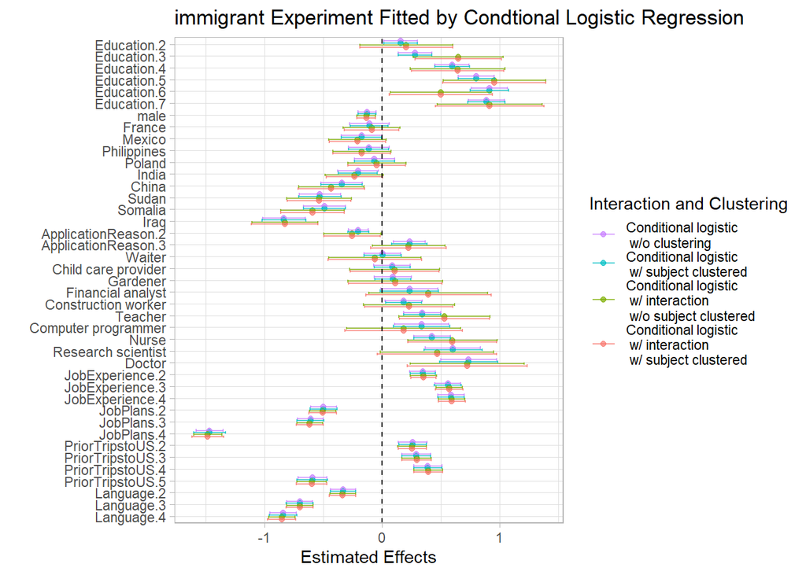

```r
cl.plot.immigrant <- est.all.immigrant %>%
  select(c(
    attribute, term, (
      contains("CL", ignore.case = F) & (starts_with("estimate.") | starts_with("CI."))
    )
  )) %>%
  filter(!grepl(":", term)) %>%  # discard interaction terms
  mutate(term = factor(term, levels = rev(term))) %>%
  pivot_longer(
    cols = -c(attribute, term),
    names_to = c(".value", "model"),
    names_pattern = "(.*)\\.(CL.*)$"
  ) %>%
  mutate(
    model = fct_recode(
      model,
      "Conditional logistic\n w/o clustering" = "CL",
      "Conditional logistic\n w/ subject clustered" = "CL_clustered",
      "Conditional logistic\n w/ interaction \n w/o subject clustered" = "CL_interact",
      "Conditional logistic\n w/ interaction \n w/ subject clustered" = "CL_interact_clustered",
    )
  ) %>%
  mutate(model = fct_rev(model)) %>%
  plot_result(., n.mod = 4) +
  labs(
    title = "immigrant Experiment Fitted by Condtional Logistic Regression",
    x = "Estimated Effects", color = "Interaction and Clustering"
  )

ggsave("./1-figure/res-immigrant-CL.png", cl.plot.immigrant)
cl.plot.immigrant
```

#### AME of Conditional Logistic Regression

```
## File Found!
## Reading file...
```

接下來是有加入交互作用的 conditional logistic regression model。

```
## File Found!
## Reading file...
```

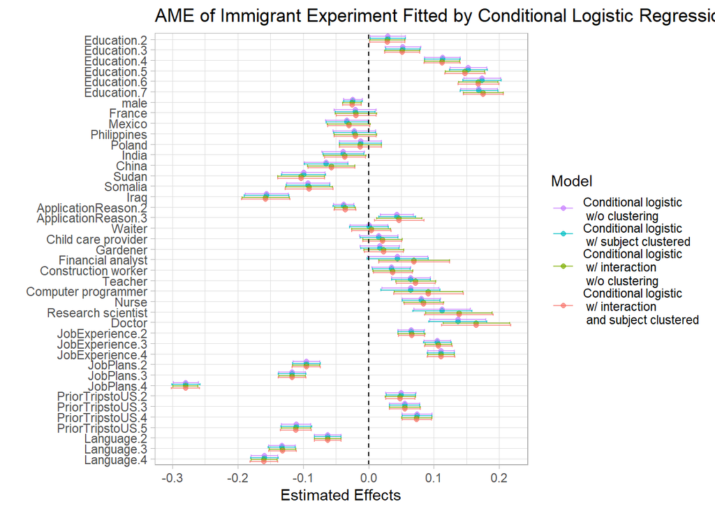

```r
AME.plot.cl <- AME.immigrant %>%
  select(c(attribute, term, contains("CL", ignore.case=F))) %>%
  mutate(term = factor(term, levels = rev(term))) %>%
  pivot_longer(
    cols = -c(attribute, term),
    names_to = c(".value", "model"),
    names_pattern = "(.*)\\.(.*)$"
  ) %>%
  mutate(
    model = fct_recode(
      model,
      "Conditional logistic\n w/o clustering" = "CL",
      "Conditional logistic\n w/ subject clustered" = "CL_clustered",
      "Conditional logistic\n w/ interaction\n w/o clustering" = "CL_interact",
      "Conditional logistic\n w/ interaction\n and subject clustered" = "CL_interact_clustered",
    )
  ) %>%
  mutate(model = fct_rev(model)) %>%
  plot_result(., n.mod = 4) +
  labs(
    title = "AME of Immigrant Experiment Fitted by Conditional Logistic Regression",
    x = "Estimated Effects", color = "Model"
  )

# ggsave("./1-figure/AME-immigrant-CL.png", AME.plot.cl)
AME.plot.cl
```

## Result Comparison

### Logistic and Conditional Logistic Regression w/ and w/o Clustering

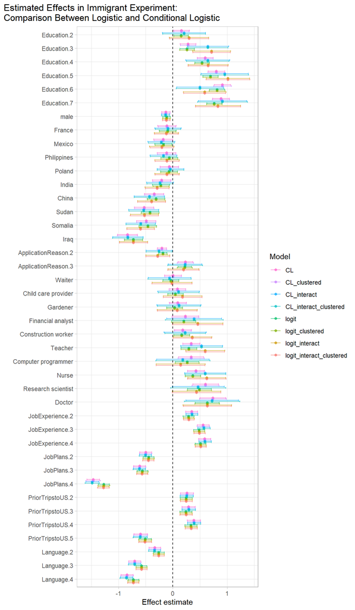

```r
est.all.immigrant %>%
  select(-contains("OLS")) %>%
  filter(!grepl(":", term)) %>%
  mutate(term = factor(term, levels = rev(term))) %>%
  pivot_longer(
    cols = -c(attribute,term),
    names_to = c(".value", "model"),
    names_pattern = "(.*)\\.(.*)$"
  ) %>%
  # mutate(
  #   model = fct_recode(
  #     model,
  #     "Logistic regression\nwithout clustering" = "logit",
  #     "Logistic regression\nwith subject clustered" = "logit_clustered",
  #     "Conditional logistic\nwithout clustering" = "CL",
  #     "Conditional logistic\nwith subject clustered" = "CL_clustered"
  #   )
  # ) %>%
  mutate(model = fct_rev(model)) %>%
  plot_result(., n.mod=4) +
  labs(
    x = "Effect estimate", col="Model",
    title = "Estimated Effects in Immigrant Experiment: \nComparison Between Logistic and Conditional Logistic"
  ) +
  theme(
      # legend.position = "bottom",
      plot.title.position = "plot"
    )
```

```r
# ggsave("./1-figure/res-immigrant-BL+CL.png")
```

### AME Comparisons

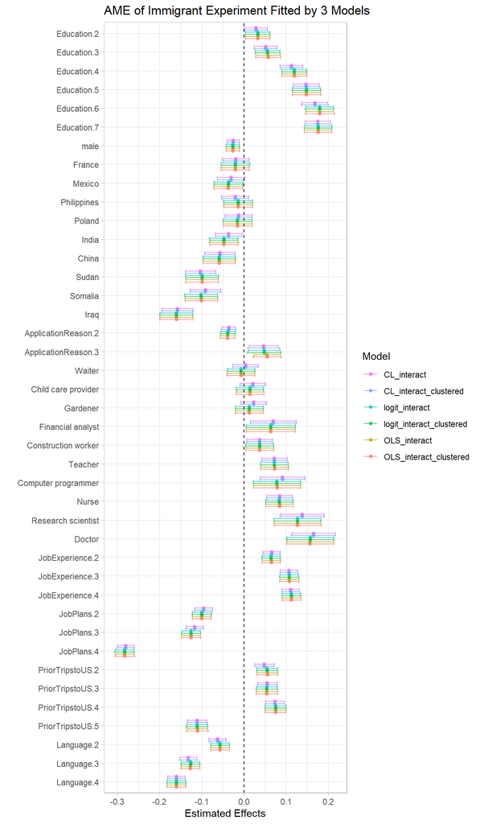

```r
AME.plot.all <- AME.immigrant %>%
  select(c(attribute, term, contains("interact"))) %>%
  mutate(term = factor(term, levels = rev(term))) %>%
  pivot_longer(
    cols = -c(attribute, term),
    names_to = c(".value", "model"),
    names_pattern = "(.*)\\.(.*)$"
  ) %>%
  # mutate(
  #   model = fct_recode(
  #     model,
  #     "Conditional logistic\n w/o clustering" = "CL",
  #     "Conditional logistic\n w/ subject clustered" = "CL_clustered",
  #     "Conditional logistic\n w/ interaction\n w/o clustering" = "CL_interact",
  #     "Conditional logistic\n w/ interaction\n and subject clustered" = "CL_interact_clustered",
  #   )
  # ) %>%
  mutate(model = fct_rev(model)) %>%
  plot_result(., n.mod = 4) +
  labs(
    title = "AME of Immigrant Experiment Fitted by 3 Models",
    x = "Estimated Effects", color = "Model"
  )

# ggsave("./1-figure/AME-immigrant-all.png", AME.plot.all)
AME.plot.all
```